# Lab assignment 1: t-tests, linear regression, analyzing lexical decision task

### Q7: an experiment where t-tests work

We raised various concerns regarding t-tests. We see that t-tests rely on independence across responses, and they assume that responses are distributed normally. The responses all have to follow the same normal distribution. And we also saw that $p$ values are hard to interpret, they depend on (often unexpressed) intentions of the researcher.

But are there experiments for which t-tests are a great fit?

In this question, try to think of an ``experiment’’ data which could appropriately be analyzed by a t-test without any data aggregation. That is, raw data are already suitable for a t-test analysis. Try to describe the experiment in as much detail as possible: what conditions would there be, what variables, which variable would function as a predictor, which should be the outcome variable? Argue why you think t-tests are suitable here (in particular, why you think the data are normal, independent, identically distributed). The word experiment is put in quotes, since you can think of an experiment very broadly - observational studies (like checking a property of houses in a town, or checking some property of students in a class) also qualifies as an experiment.

*Checking the high school entry exam results for students that were taught by different teachers for a certain subject. In this way, we don’ t need to aggregate data, since per participant we will have only one value, the exam score or percentage. We also assume that the groups are of equal size. The performance on the exam for each participant should be independent of others. Classes have usually over 30 students and a teacher could teach 3 or 4 classes, so the sample would be big enough. A two sample t-test should ideally be applied in this case, since we have 2 groups and we could consider the control group to be the one with the usual teacher and the experimental one with a teacher that is just starting teaching and is maybe using a different method.*

### Q8: Linear models and graphical representation

Run the models above (m1 and m2). Report results of both of them.

Then, provide a graphical summary accompanying m2. The summary should show how Accuracy and IsWord affect RTs. In your plot we should be able to see differences in the outcomes when the values of the predictor changes. That is, we should be able to see that RTs change when the values of IsWord change, and that RTs change when the values of ACC change, and that IsWord and ACC interact in affecting RTs.

```r
m1 <- lm(RT ~ IsWord, merged_data)#put in your data here
print(summary(m1))
```

[output not shown]

We can add more parameters and study how they affect the regression line that predicts RTs. For example, the following model would consider the effect of IsWord, Accuracy and their interaction. The * in the notation calculates the main effect of both factors and the interaction of the two factors.

```r
m2 <- lm(RT ~ IsWord * ACC, merged_data)#put in your data here
print(summary(m2))

# The * sign signals interaction. See ?formula for details.

# Load necessary libraries
library(ggplot2)

# Predict response times using model m2
predictions <- expand.grid(IsWord = c(FALSE, TRUE), ACC = c(FALSE, TRUE))
predictions$RT <- predict(m2, newdata = predictions)

# Plotting
ggplot(predictions, aes(x = ACC, y = RT, color = factor(IsWord))) +
  geom_point() +
  geom_line(aes(group = IsWord), linetype = "dashed") +
  labs(x = "Accuracy", y = "Response Time", color = "Is Word") +
  theme_minimal()
```

[output not shown]

### Q9: What frequency is the best predictor?

There are various sources of frequency in our dataset: FreCOCA, FreqGoogle, FreqSUBTLEX and FreqCOCAspok. These are frequencies of words collected from four different corpora. Find out which of these provides the best fit of the model to the log-transformed reaction times. You can do so by comparing models in which different frequency sources are added, or by comparing how big a proportion of the variance is explained by the model.

After you find the answer, use the same frequency to address the following observation: it has been claimed that log-frequency of a word is a good predictor, better than a plain frequency, for log-reaction times. Is this correct? Plot the relation between the outcome variable and the non-transformed predictor variable to see whether any clear relation can be observed and whether the relation looks linear. Then, transform the frequency to log and plot again. Then, check the resulting model.

Finally, check whether the log-transformation of all frequency data sets changes your previous answer. Which corpus of frequency is now the best predictor when we consider its log-transformation?

```r
# 1
# Fit linear regression models using each frequency
model_FreqCOCA <- lm(log(RT) ~ FreqCOCA,merged_data)
model_FreqGoogle <- lm(log(RT) ~ FreqGoogle, merged_data)
model_FreqSUBTLEX <- lm(log(RT) ~ FreqSUBTLEX,  merged_data)
model_FreqCOCAspok <- lm(log(RT) ~ FreqCOCAspok, merged_data)

# Compare values
rsquared_values <- tibble(
  Source = c("FreqCOCA", "FreqGoogle", "FreqSUBTLEX", "FreqCOCAspok"),
  R_squared = c(summary(model_FreqCOCA)$r.squared,
                summary(model_FreqGoogle)$r.squared,
                summary(model_FreqSUBTLEX)$r.squared,
                summary(model_FreqCOCAspok)$r.squared)
)

# Print R-squared values
print(rsquared_values)
```

```
## # A tibble: 4 × 2
##   Source       R_squared
##   <chr>            <dbl>
## 1 FreqCOCA      0.000728
## 2 FreqGoogle    0.00102
## 3 FreqSUBTLEX   0.000662
## 4 FreqCOCAspok  0.000763
```

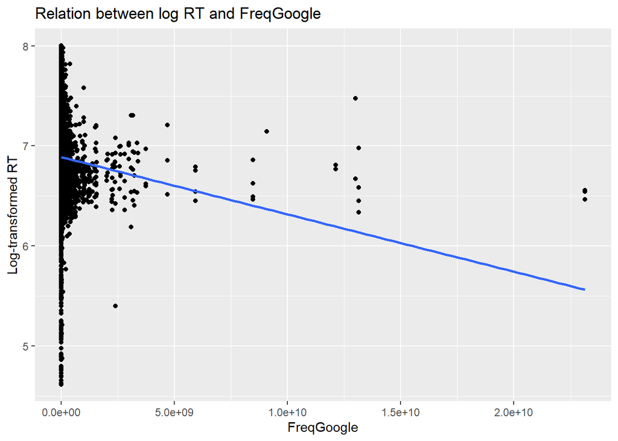

```r
# 2
# Biggest value for FreqGoogle =>

# Plot relation between log-transformed RT and FreqGoogle
ggplot(merged_data, aes(x = FreqGoogle, y = log(RT))) +
  geom_point() +
  geom_smooth(method = "lm", se = FALSE) +
  labs(x = "FreqGoogle", y = "Log-transformed RT") +
  ggtitle("Relation between log RT and FreqGoogle")
```

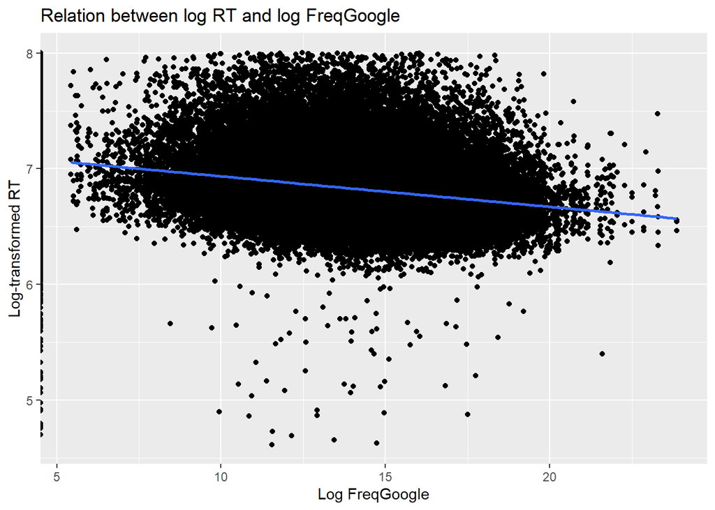

```r
# Transform FreqGoogle to log scale
# merged_data$log_FreqGoogle <- log(merged_data$FreqGoogle)

# Plot relation between log-transformed RT and log-transformed FreqGoogle
ggplot(merged_data, aes(x = log(FreqGoogle), y = log(RT))) +
  geom_point() +
  geom_smooth(method = "lm", se = FALSE) +
  labs(x = "Log FreqGoogle", y = "Log-transformed RT") +
  ggtitle("Relation between log RT and log FreqGoogle")
```

```r
# 3
# this part doesn't work yet
# Fit linear regression models using each frequency
# merged_data$log_FreqCOCA <- as.factor(log(merged_data$FreqCOCA))
# merged_data$log_FreqCOCA <- log(merged_data$FreqCOCA)
merged_data$FreqCOCA <- replace(merged_data$FreqCOCA, merged_data$FreqCOCA == 0, NA)
merged_data$FreqGoogle <- replace(merged_data$FreqGoogle, merged_data$FreqGoogle == 0, NA)
merged_data$FreqSUBTLEX <- replace(merged_data$FreqSUBTLEX, merged_data$FreqSUBTLEX == 0, NA)
merged_data$FreqCOCAspok <- replace(merged_data$FreqCOCAspok, merged_data$FreqCOCAspok == 0, NA)
model_logFreqCOCA <- lm(log(RT) ~ log(FreqCOCA) ,merged_data, na.action = "na.omit")
model_logFreqGoogle <- lm(log(RT) ~  log(FreqGoogle),merged_data)
model_logFreqSUBTLEX <- lm(log(RT) ~ log(FreqSUBTLEX), merged_data)
model_logFreqCOCAspok <- lm(log(RT) ~ log(FreqCOCAspok), merged_data)

# Compare values
rsquared_values <- tibble(
  Source = c("FreqCOCA", "FreqGoogle", "FreqSUBTLEX", "FreqCOCAspok"),
  R_squared = c(summary(model_logFreqCOCA)$r.squared,
                summary(model_logFreqGoogle)$r.squared,
                summary(model_logFreqSUBTLEX)$r.squared,
                summary(model_logFreqCOCAspok)$r.squared)
)

# Print R-squared values
print(rsquared_values)
```

```
## # A tibble: 4 × 2
##   Source       R_squared
##   <chr>            <dbl>
## 1 FreqCOCA        0.0545
## 2 FreqGoogle      0.0524
## 3 FreqSUBTLEX     0.0519
## 4 FreqCOCAspok    0.0406
```

```r
# The answer to which corpus of frequency is now the best predictor when we consider its log-transformation is now FreqCOCA.
```

### Q10: Experiment design

You are asked to design an experiment that will test whether log frequency or plain frequency is the right predictor of log reaction times (so, you basically want to test your answer to Q9, but rather than using a corpus data, you want to test your answer in a novel experiment). Your experiment should be a lexical decision task. What will the design be like? Describe (i) the conditions in your experiments, (ii) at least two items in your experiment (these should be words used in the lexical decision task), (iii) what fillers and control items you would use, (iv) how many stimuli would the whole experiment consist of, (v) what log-frequency predicts and what plain frequency predicts as results in your experiment.

*I asked chatGPT if verb vs noun was also a lexical decision task, but that was not the case, so we chose for a traditional word vs nonword task. I also asked chatGPT what log frequencies were and how that would be a condition for a participant. Lastly I asked for a definition of control and fillers, as I could not find a real definition from literature.*

*(i) The first factor is sentences with all words versus sentences containing words and one non word, the second factor is plain versus log frequency. But this still gives the participant 2 conditions when they perform the experiment, word and nonword. The other factor will be implemented in the data-analysis.*

2. *Some words are:* *“This is an apple”* *“I love banana”* *“I do not own a house”*

*Some non-words are:* *“I would like some slsai”* *“plors are fun*”* ”sljdfl”*

3. *Fillers should distract the participant from the main purpose of the study, a filler would be a mathematical formula instead of words. A control should serve as a baseline, a control would be one word or one pseudoword, removed from the sentence.*

*(v)* *We then can see in the data-analysis if the plain frequencies are better predictors of log reaction time or of log frequencies are better predictors of log reaction time (that is, if it is a better predictor and a word is more frequent, then the reaction time should also change with it, like being shorter). We can see which predictors have significant relationships with the log reaction times. If the log frequencies have better predictive value of the log reaction times, then this would mean that it would be better for the model to have log frequencies. And the same with plain frequencies.*

## Bibliography

Arehalli, S., & Wittenberg, E. (2021). Experimental filler design influences error correction rates in a word restoration paradigm. Linguistics Vanguard, 7(1). https://doi.org/10.1515/lingvan-2020-0052

Marinis, T., & Cunnings, I. (2018). 10. Using Psycholinguistic Techniques in a Second Language Teaching Setting. In Multilingual Matters eBooks (pp. 185–202). https://doi.org/10.21832/9781788921626-012

Tucker, Benjamin V, Daniel Brenner, D Kyle Danielson, Matthew C Kelley, Filip Nenadic, and Michelle Sims. 2019. *The massive auditory lexical decision (MALD) database.* Behavior research methods 51:1187–1204.